# Statistical Inference Notes

Howard J

December 14, 2017

```r
library(UsingR)
library(tidyverse)
library(grid)
library(png)
```

## Asymptotics

**Asymptotics**: the behavior of statistics as the sample size limits to infinity. Asymptotics generally give no assurances about finite sample performance and form the basis for frequency interpretation of probabilities (the long run proportion of times an event occurs).

### Limits of random variables

Fortunately, for the sample mean there’s a set of powerful results. These results allow us to talk about the *large sample distribution of sample means of a collection of $iid$ observations*.

**Law of Large Numbers**: that the average limits to what its estimating, the population mean. The LLN forms the basis of frequency style thinking.

*Example:* $\bar X_n$ could be the average of the result of $n$ coin flips (i.e. the sample proportion of heads). As we flip a fair coin over and over, it evetually converges to the true probability of a head. An good estimator is **Consistent** if it converges to what you want to estimate. The **LLN** says that the sample mean of iid sample is consistent for the *population mean.*

The *sample variance* and the *sample standard deviation* of iid random variables are consistent as well.

**LLN, sample average of standard normal distribution**

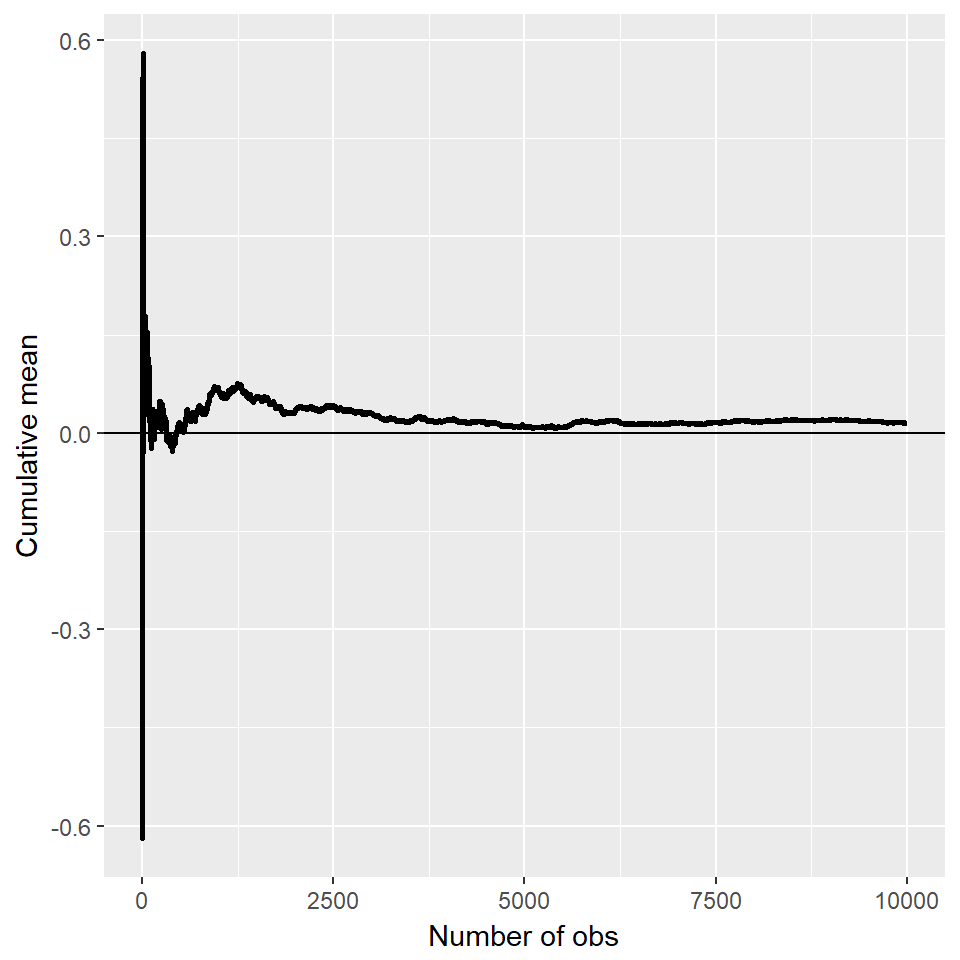

```r
# n - total count of trials, count of observations, or sample size
# x_val - number of trials, or number of observations
# y_val - cumulative means
n <- 10000
df <- data_frame(x_val = 1:n, y_val = cumsum(rnorm(n))/(1:n))
ggplot(df, aes(x=x_val, y=y_val)) +
    geom_hline(yintercept=0) +
    geom_line(size=1) +
    labs(x="Number of obs", y="Cumulative mean")
```

**LLN, sample average of coin flips**

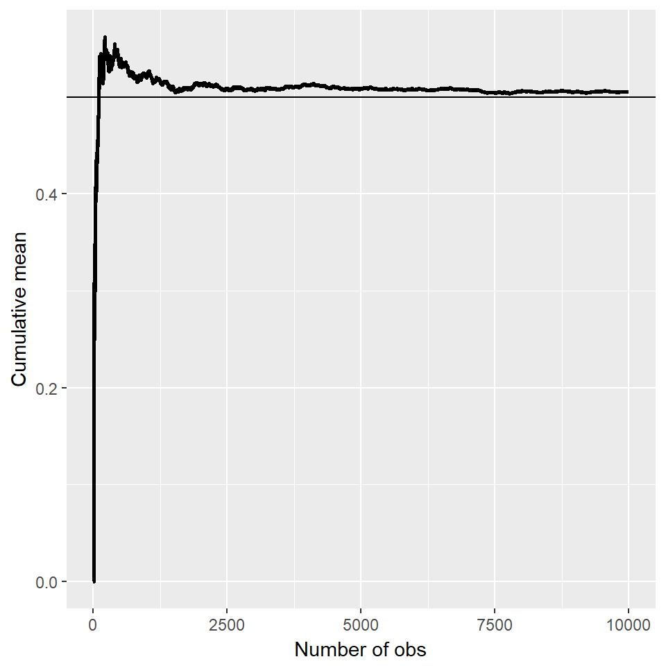

```r
# n - total count of trials, count of observations, or sample size
# x_val - number of trials, or number of observations
# y_val - cumulative means
n <- 10000
df <- data.frame(x_val=1:n, y_val=cumsum(sample(0:1,n,replace=TRUE))/(1:n))
ggplot(df, aes(x=x_val, y=y_val)) +
    geom_hline(yintercept=0.5) +
    geom_line(size=1) +
    labs(x="Number of obs", y="Cumulative mean")
```

### The Central Limit Theorem

The **CLT**: the distribution of averages of iid variables (properly normalized) becomes that of a standard normal as the sample size increases.

$$\frac{\bar X_n - \mu}{\sigma / \sqrt{n}}=
= \frac{\mbox{Estimate} - \mbox{Mean of estimate}}{\mbox{Std. Err. of estimate}}$$

$$\frac{\bar X_n - \mu}{\sigma / \sqrt{n}}=
\frac{\sqrt n (\bar X_n - \mu)}{\sigma}$$

has a distribution like that of a standard normal for large $n$.

- (Replacing the standard error by its estimated value doesn’t change the CLT)
- The useful way to think about the CLT is that $\bar X_n$ is approximately $N(\mu, \sigma^2 / n)$

### CLT, Die rolling experiment

*Example:* simulate a standard normal random variable by rolling $n$ (six sided). $X_i$ be the outcome for die $i$. Thus,
$$\mu=E[X_i]=3.5$$
$$Var(X_i)=2.92$$
$$SE=\sqrt{2.92 / n}=1.71 / \sqrt{n}$$

Lets roll $n$ dice, take their mean, subtract off 3.5, and divide by $1.71 / \sqrt{n}$ and repeat this over and over:

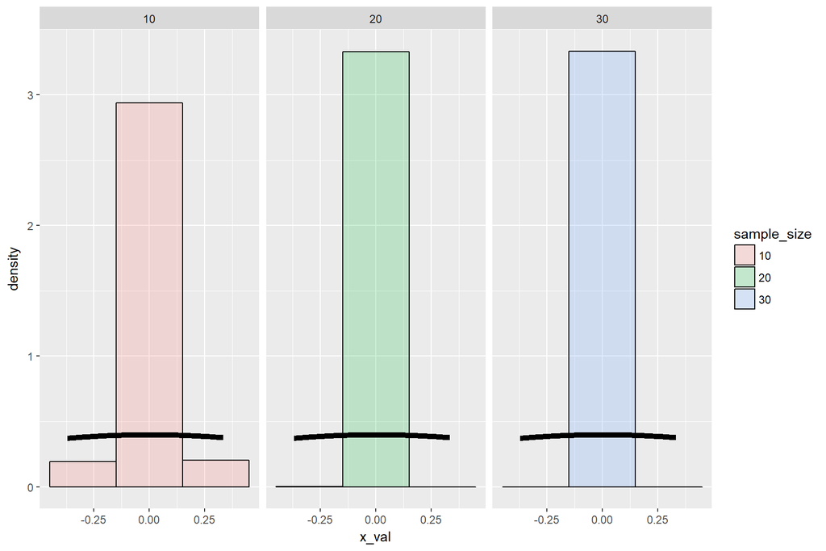

```r
# n - total count of trials, or sample size
sim_count <- 1000
cfunc <- function(x, n) (mean(x) - 3.5) / 1.71 / sqrt(n)
df <- data.frame(
  x_val=c(apply(matrix(sample(1:6, sim_count*10, replace=TRUE), sim_count), 1, cfunc, 10),
        apply(matrix(sample(1:6, sim_count*20, replace=TRUE), sim_count), 1, cfunc, 20),
        apply(matrix(sample(1:6, sim_count*30, replace=TRUE), sim_count), 1, cfunc, 30)
        ),
  sample_size=factor(rep(c(10, 20, 30), rep(sim_count, 3))))
ggplot(df, aes(x=x_val, fill=sample_size)) +
    geom_histogram(alpha=.20, binwidth=.3, colour="black", aes(y=..density..)) +
    stat_function(fun=dnorm, size=2) +
    facet_grid(. ~ sample_size)
```

### CLT, Coin flipping

Let $X_i$ be the $0$ or $1$ result of the $i^{th}$ flip of a possibly unfair coin. The sample proportion, say $\hat p$, is the average of the coin flips.
$$E[X_i] = p$$
$$Var(X_i) = p(1-p)$$
Thus, $\sigma = \sqrt{p(1-p)/n}$

$$\frac{\hat p - p}{\sqrt{p(1-p)/n}}$$
will be approximately normally distributed. Let’s flip a coin $n$ times, take the sample proportion of heads, subtract off .5 and multiply the result by $2 \sqrt{n}$ (divide by $1/(2 \sqrt{n})$)

## Simulation results

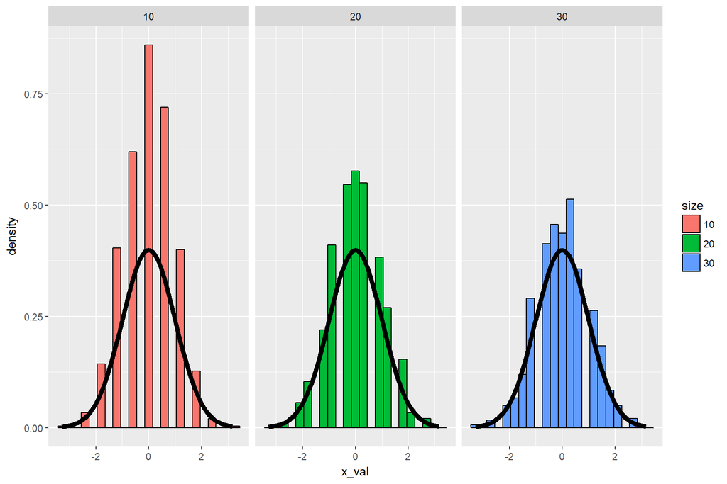

```r
sim_count <- 1000
cfunc <- function(x, n) 2*sqrt(n)*(mean(x) - 0.5)
df <- data.frame(
  x_val=c(apply(matrix(sample(0:1, sim_count*10, replace=TRUE), sim_count), 1, cfunc, 10),
        apply(matrix(sample(0:1, sim_count*20, replace=TRUE), sim_count), 1, cfunc, 20),
        apply(matrix(sample(0:1, sim_count*30, replace=TRUE), sim_count), 1, cfunc, 30)
        ),
  size=factor(rep(c(10, 20, 30), rep(sim_count, 3))))

ggplot(df, aes(x=x_val, fill=size)) + geom_histogram(binwidth=.3, colour="black", aes(y=..density..)) +
    stat_function(fun=dnorm, size=2) +
    facet_grid(. ~ size)
```

## Simulation results, $p=0.9$

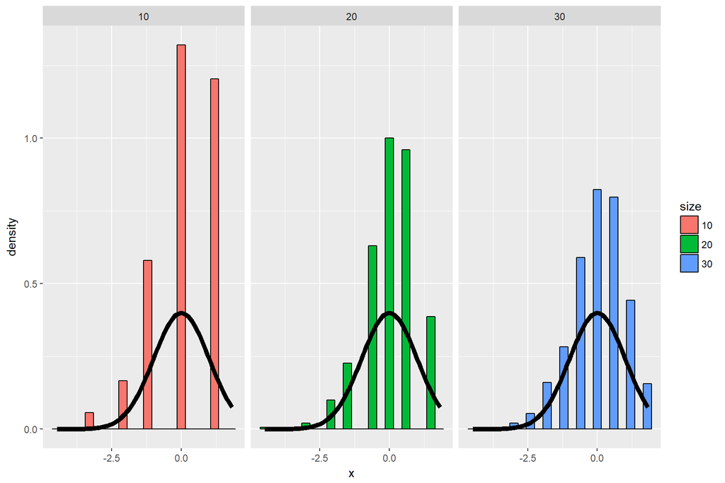

```r
sim_count <- 1000
cfunc <- function(x, n) sqrt(n)*(mean(x) - 0.9) / sqrt(.1*.9)
df <- data.frame(
  x=c(apply(matrix(sample(0:1, prob=c(.1,.9), sim_count*10, replace=TRUE), sim_count), 1, cfunc, 10),
        apply(matrix(sample(0:1, prob=c(.1,.9), sim_count*20, replace=TRUE), sim_count), 1, cfunc, 20),
        apply(matrix(sample(0:1, prob=c(.1,.9), sim_count*30, replace=TRUE), sim_count), 1, cfunc, 30)
        ),
  size=factor(rep(c(10, 20, 30), rep(sim_count, 3))))
ggplot(df, aes(x=x, fill=size)) +
    geom_histogram(binwidth=.3, colour="black", aes(y=..density..)) +
    stat_function(fun=dnorm, size=2) +
    facet_grid(. ~ size)
```

## Sample proportions

- In the event that each $X_i$ is $0$ or $1$ with common success probability $p$ then $\sigma^2=p(1 - p)$
- The interval takes the form
  $$\hat p \pm z_{1 - \alpha/2} \sqrt{\frac{p(1 - p)}{n}}$$
- Replacing $p$ by $\hat p$ in the standard error results in what is called a Wald confidence interval for $p$
- For 95% intervals
  $$\hat p \pm \frac{1}{\sqrt{n}}$$
  is a quick CI estimate for $p$

## Binomial interval

```r
.56 + c(-1, 1)*qnorm(.975)*sqrt(.56*.44 / 100)
```

```
## [1] 0.4627099 0.6572901
```

```r
binom.test(56, 100)$conf.int
```

```
## [1] 0.4571875 0.6591640
## attr(,"conf.level")
## [1] 0.95
```

## Simulation

```r
n <- 20; pvals <- seq(.1, .9, by=.05); sim_count <- 1000
coverage <- sapply(pvals, function(p){
  phats <- rbinom(sim_count, prob=p, size=n) / n
  ll <- phats - qnorm(.975)*sqrt(phats*(1 - phats) / n)
  ul <- phats + qnorm(.975)*sqrt(phats*(1 - phats) / n)
  mean(ll < p & ul > p)
})
```

[output not shown]

## What’s happening?

- $n$ isn’t large enough for the CLT to be applicable for many of the values of $p$
- Quick fix, form the interval with
  $$\frac{X + 2}{n + 4}$$
- (Add two successes and failures, Agresti/Coull interval)

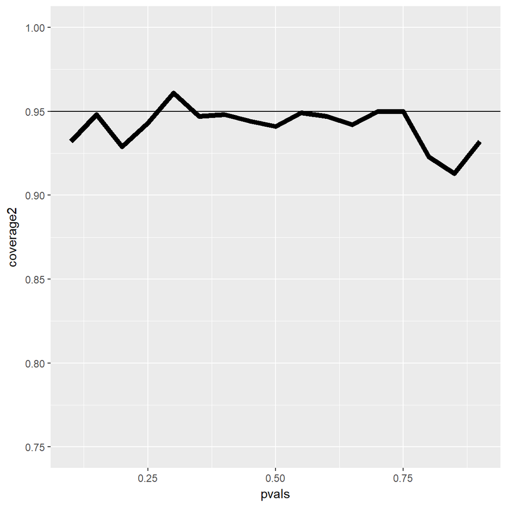

```r
ggplot(data.frame(pvals, coverage), aes(x=pvals, y=coverage2)) + geom_line(size=2) + geom_hline(yintercept=0.95)+ ylim(.75, 1.0)
```

## Adding 2 successes and 2 failures

(It’s a little conservative)

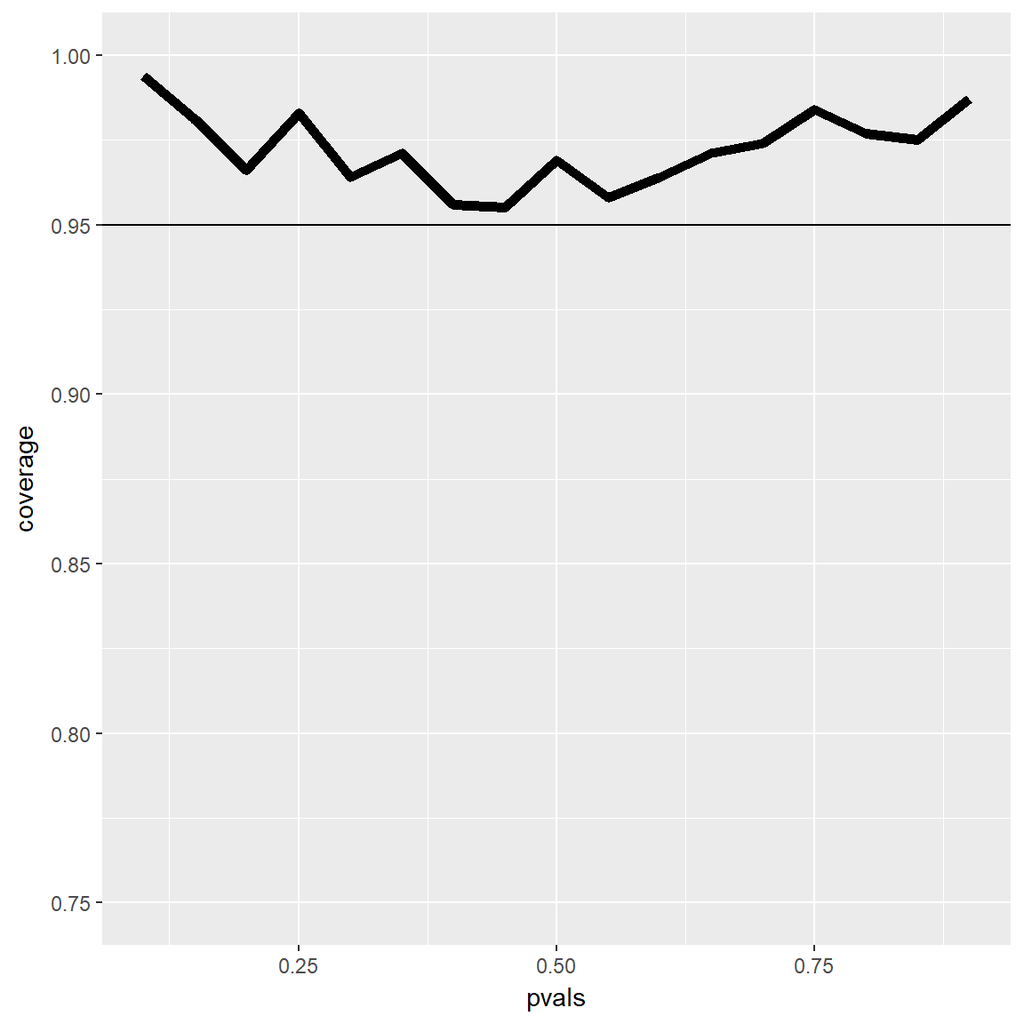

```r
ggplot(data.frame(pvals, coverage), aes(x=pvals, y=coverage)) + geom_line(size=2) + geom_hline(yintercept=0.95)+ ylim(.75, 1.0)
```

## Simulating the Poisson coverage rate

Let’s see how this interval performs for lambda values near what we’re estimating

```r
lambdavals <- seq(0.005, 0.10, by=.01); sim_count <- 1000
t <- 100
coverage <- sapply(lambdavals, function(lambda){
  lhats <- rpois(sim_count, lambda=lambda*t) / t
  ll <- lhats - qnorm(.975)*sqrt(lhats / t)
  ul <- lhats + qnorm(.975)*sqrt(lhats / t)
  mean(ll < lambda & ul > lambda)
})
```

## Covarage

(Gets really bad for small values of lambda)

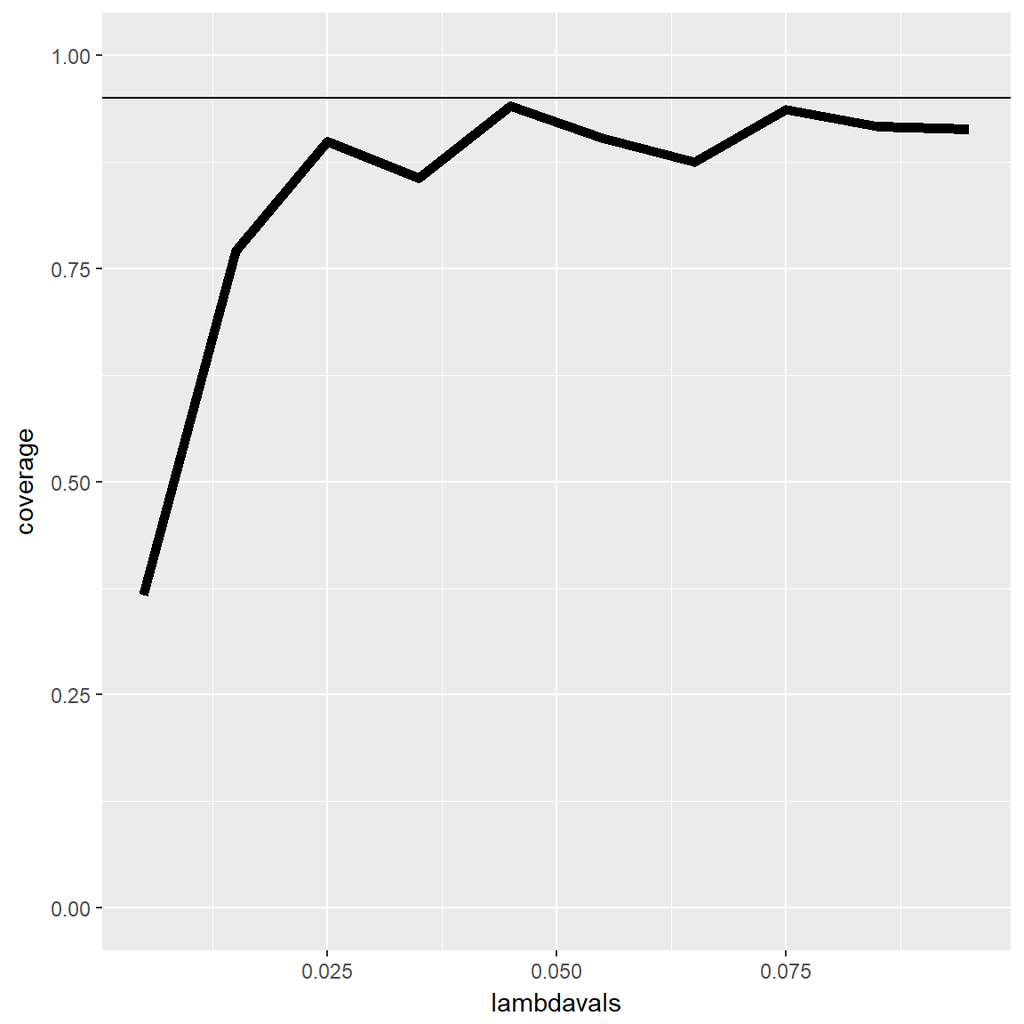

```r
ggplot(data.frame(lambdavals, coverage), aes(x=lambdavals, y=coverage)) + geom_line(size=2) + geom_hline(yintercept=0.95)+ylim(0, 1.0)
```

## What if we increase t to 1000?

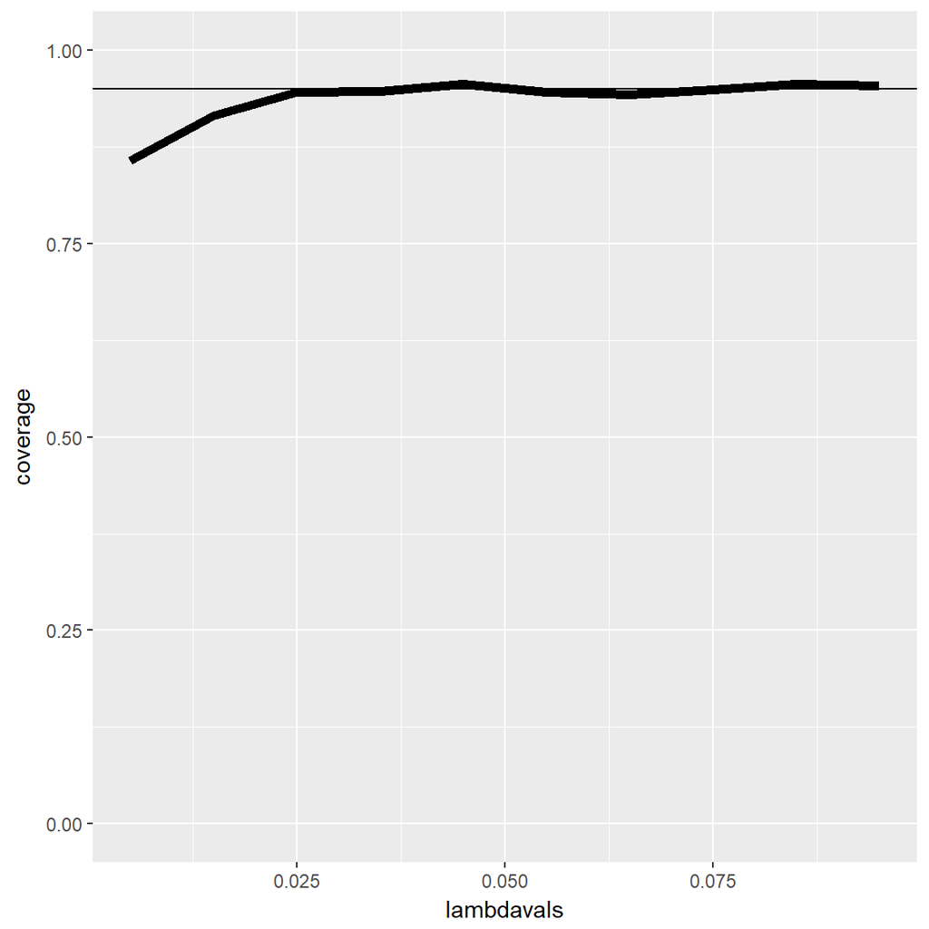

```r
lambdavals <- seq(0.005, 0.10, by=.01)
sim_count <- 1000
t <- 1000
coverage <- sapply(lambdavals, function(lambda){
  lhats <- rpois(sim_count, lambda=lambda*t) / t
  ll <- lhats - qnorm(.975)*sqrt(lhats / t)
  ul <- lhats + qnorm(.975)*sqrt(lhats / t)
  mean(ll < lambda & ul > lambda)
})
ggplot(data.frame(lambdavals, coverage), aes(x=lambdavals, y=coverage)) + geom_line(size=2) + geom_hline(yintercept=0.95) + ylim(0, 1.0)
```

The **LLN** states that averages of iid samples converge to the population means that they are estimating.  
The **CLT** states that averages are approximately normal, with distributions.  
* Centered at the population mean  
* with standard deviation equal to the standard error of the mean  
* CLT gives no guarantee that $n$ is large enough  
Taking the mean and adding and subtracting the relevant normal quantile times the SE yields a **Confidence Interval** for the mean. Adding and subtracting 2 SEs works for 95% intervals.  
* Confidence intervals get narrower with less variability or larger sample sizes.  
* The Poisson and binomial case have exact intervals that don’t require the CLT. But a quick fix for small sample size binomial calculations is to add 2 successes and failures